# Regression Project - MPG Analysis for Motor Trend

Conrad Wong

November 7, 2015

# Executive Summary

### This analysis will use the mtcars dataset to analyze if there is a difference in MPG between manual and automatic cars. These are the steps to be followed:

### - Data transformation and exploratory data analysis to get a sense of the shape and relationship of the different variables

### - Find the best regression model that maximizes the percentage of variance in MPG

### - Drive conclusions for two questions:

```
 - Is an automatic or manual transmission better for MPG?
 - Quantify the MPG difference between automatic and manual transmissions
```

# Data transformation and exploratory data analysis

```r
library(ggplot2)
library(GGally)
library(car)
library(knitr)

data <- mtcars

data$trans <- as.factor(ifelse(mtcars$am==0, "Auto", "Manual"))
data <- data[, -9]
data$vs <- as.factor(ifelse(data$vs==0, "V", "Straight"))
data$cyl <- as.factor(data$cyl)
data$carb <- as.factor(data$carb)
data$gear <- as.factor(data$gear)

str(data)
```

```
## 'data.frame':    32 obs. of  11 variables:
##  $ mpg  : num  21 21 22.8 21.4 18.7 18.1 14.3 24.4 22.8 19.2 ...
##  $ cyl  : Factor w/ 3 levels "4","6","8": 2 2 1 2 3 2 3 1 1 2 ...
##  $ disp : num  160 160 108 258 360 ...
##  $ hp   : num  110 110 93 110 175 105 245 62 95 123 ...
##  $ drat : num  3.9 3.9 3.85 3.08 3.15 2.76 3.21 3.69 3.92 3.92 ...
##  $ wt   : num  2.62 2.88 2.32 3.21 3.44 ...
##  $ qsec : num  16.5 17 18.6 19.4 17 ...
##  $ vs   : Factor w/ 2 levels "Straight","V": 2 2 1 1 2 1 2 1 1 1 ...
##  $ gear : Factor w/ 3 levels "3","4","5": 2 2 2 1 1 1 1 2 2 2 ...
##  $ carb : Factor w/ 6 levels "1","2","3","4",..: 4 4 1 1 2 1 4 2 2 4 ...
##  $ trans: Factor w/ 2 levels "Auto","Manual": 2 2 2 1 1 1 1 1 1 1 ...
```

### Key Findings: The pairs plot (Figure 1 in the Appendix) suggest there might be some colinearity between the variables in the mtcars dataset, as there are some pair that are highly correlated, for example:

- disp and weight with corr= 0.89
- disp and hp with corr = 0.79

# Model selection

## Model 1: Fit of mpg by transmission

```r
fit.by.trans <- lm(mpg~trans, data=data)
summary(fit.by.trans)
```

```
##
## Call:
## lm(formula = mpg ~ trans, data = data)
##
## Residuals:
##     Min      1Q  Median      3Q     Max
## -9.3923 -3.0923 -0.2974  3.2439  9.5077
##
## Coefficients:
##             Estimate Std. Error t value Pr(>|t|)
## (Intercept)   17.147      1.125  15.247 1.13e-15 ***
## transManual    7.245      1.764   4.106 0.000285 ***
## ---
## Signif. codes:  0 '***' 0.001 '**' 0.01 '*' 0.05 '.' 0.1 ' ' 1
##
## Residual standard error: 4.902 on 30 degrees of freedom
## Multiple R-squared:  0.3598, Adjusted R-squared:  0.3385
## F-statistic: 16.86 on 1 and 30 DF,  p-value: 0.000285
```

### Key Findings: Fitting by transmission results in a statistical significant coefficient (p-value < 0.05), but the adjusted r2 is only 0.34. Need to look for other variables that help explain a bigger percentage of the variance in mpg. Next step is to fit a model with all variables

## Model 2: Fit of mpg by all variables in the mtcars dataset

```r
fit.by.all <- lm (mpg~. , data=data)
summary(fit.by.all)
```

```
##
## Call:
## lm(formula = mpg ~ ., data = data)
##
## Residuals:
##     Min      1Q  Median      3Q     Max
## -3.5087 -1.3584 -0.0948  0.7745  4.6251
##
## Coefficients:
##             Estimate Std. Error t value Pr(>|t|)
## (Intercept) 25.80998   20.26413   1.274   0.2222
## cyl6        -2.64870    3.04089  -0.871   0.3975
## cyl8        -0.33616    7.15954  -0.047   0.9632
## disp         0.03555    0.03190   1.114   0.2827
## hp          -0.07051    0.03943  -1.788   0.0939 .
## drat         1.18283    2.48348   0.476   0.6407
## wt          -4.52978    2.53875  -1.784   0.0946 .
## qsec         0.36784    0.93540   0.393   0.6997
## vsV         -1.93085    2.87126  -0.672   0.5115
## gear4        1.11435    3.79952   0.293   0.7733
## gear5        2.52840    3.73636   0.677   0.5089
## carb2       -0.97935    2.31797  -0.423   0.6787
## carb3        2.99964    4.29355   0.699   0.4955
## carb4        1.09142    4.44962   0.245   0.8096
## carb6        4.47757    6.38406   0.701   0.4938
## carb8        7.25041    8.36057   0.867   0.3995
## transManual  1.21212    3.21355   0.377   0.7113
## ---
## Signif. codes:  0 '***' 0.001 '**' 0.01 '*' 0.05 '.' 0.1 ' ' 1
##
## Residual standard error: 2.833 on 15 degrees of freedom
## Multiple R-squared:  0.8931, Adjusted R-squared:  0.779
## F-statistic:  7.83 on 16 and 15 DF,  p-value: 0.000124
```

```r
vif(fit.by.all)
```

```
##             GVIF Df GVIF^(1/(2*Df))
## cyl   128.120962  2        3.364380
## disp   60.365687  1        7.769536
## hp     28.219577  1        5.312210
## drat    6.809663  1        2.609533
## wt     23.830830  1        4.881683
## qsec   10.790189  1        3.284842
## vs      8.088166  1        2.843970
## gear   50.852311  2        2.670408
## carb  503.211851  5        1.862838
## trans   9.930495  1        3.151269
```

### Key Findings: Fitting by all variables in the mtcars dataset increases the adjusted r2 to 0.78, but non of the coefficients is statistical significant (p-value < 0.05). Looking at the VIF values, suggests that there is colinearity between the variables. Next step is to remove the ones with a high GVIF^(1/(2*Df)) value.

## Model 3: Fit of mpg by all variables where GVIF^(1/(2*Df)) <= 3.15

```r
#            GVIF Df GVIF^(1/(2*Df))
#drat    6.809663  1        2.609533
#vs      8.088166  1        2.843970
#gear   50.852311  2        2.670408
#carb  503.211851  5        1.862838
#trans   9.930495  1        3.151269

fit.by.some <- lm(mpg~ drat + vs + gear + carb + trans, data=data )
summary(fit.by.some)
```

```
##
## Call:
## lm(formula = mpg ~ drat + vs + gear + carb + trans, data = data)
##
## Residuals:
##    Min     1Q Median     3Q    Max
## -5.586 -1.102  0.000  1.304  4.721
##
## Coefficients:
##             Estimate Std. Error t value Pr(>|t|)
## (Intercept)   11.116      6.536   1.701   0.1038
## drat           3.075      2.027   1.517   0.1441
## vsV           -1.484      2.373  -0.625   0.5386
## gear4          2.593      2.935   0.884   0.3869
## gear5          2.358      3.569   0.661   0.5159
## carb2         -1.855      2.164  -0.857   0.4010
## carb3         -2.772      2.905  -0.954   0.3509
## carb4         -7.217      2.640  -2.734   0.0124 *
## carb6         -5.915      4.407  -1.342   0.1939
## carb8        -10.369      4.428  -2.342   0.0291 *
## transManual    2.494      2.565   0.972   0.3420
## ---
## Signif. codes:  0 '***' 0.001 '**' 0.01 '*' 0.05 '.' 0.1 ' ' 1
##
## Residual standard error: 2.902 on 21 degrees of freedom
## Multiple R-squared:  0.8429, Adjusted R-squared:  0.7681
## F-statistic: 11.27 on 10 and 21 DF,  p-value: 2.295e-06
```

```r
vif(fit.by.some)[,3]^2
```

```
##     drat       vs     gear     carb    trans
## 4.321481 5.265793 3.896788 1.517639 6.028156
```

### Key Findings: The adjusted r2 decreases to 0.77, but we still have the problem of non statistical significant coefficients. Next step is to fit the model by a stepwise algorithm.

## Model 4: Fit of mpg following the stepwise algorithm

```r
stepModel <- step(fit.by.all, k=log(dim(data)[1]), trace=FALSE)
summary(stepModel)
```

```
##
## Call:
## lm(formula = mpg ~ wt + qsec + trans, data = data)
##
## Residuals:
##     Min      1Q  Median      3Q     Max
## -3.4811 -1.5555 -0.7257  1.4110  4.6610
##
## Coefficients:
##             Estimate Std. Error t value Pr(>|t|)
## (Intercept)   9.6178     6.9596   1.382 0.177915
## wt           -3.9165     0.7112  -5.507 6.95e-06 ***
## qsec          1.2259     0.2887   4.247 0.000216 ***
## transManual   2.9358     1.4109   2.081 0.046716 *
## ---
## Signif. codes:  0 '***' 0.001 '**' 0.01 '*' 0.05 '.' 0.1 ' ' 1
##
## Residual standard error: 2.459 on 28 degrees of freedom
## Multiple R-squared:  0.8497, Adjusted R-squared:  0.8336
## F-statistic: 52.75 on 3 and 28 DF,  p-value: 1.21e-11
```

### Key Findings: This approach results in the hightest adjusted r2: 0.83, and it find three coefficients that are statistical significant (wt, qsec and transmission). Next step is to run some diagnostics for this model

```r
#dfb <- round(dfbetas(stepModel)[, 4], 3)

#Edfb <- as.data.frame(sort(dfb, decreasing=TRUE))
#colnames(dfb) <- c("Transmission")

#kable(dfb)
```

# Conclusion

## Is an automatic or manual transmission better for MPG?

### - This analysis confirms that manual cars deliver more MPG than automatic cars

## Quantify the MPG difference between automatic and manual transmissions

```r
coef <- summary(stepModel)$coefficients
coef[4,1] + c(-1, 1) * qt(.975, df = stepModel$df) * coef[4, 2]
```

```
## [1] 0.04573031 5.82594408
```

### - With 95% confidence, we estimate that manual cars deliver between 0.05 and 5.82 more MPG than automatic cars.

# Appendix

## Figure 1: GGPairs

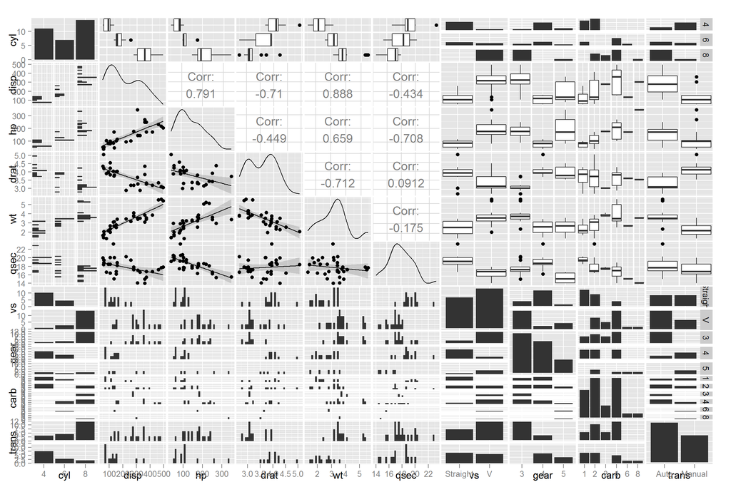

```r
ggpairs(data[, 2:11], lower=list(continuous="smooth"))
```